# Pertemuan 6&7 - Pemodelan Data

Nyayu Azzahra Nabila

2025-10-02

## 1 Packages

```r
library(ggplot2)
library(tsibble)
library(tseries)
library(MASS)
library(forecast)
library(TSA)
library(TTR)
library(aTSA)
library(graphics)
```

## 2 Input Data

Import data kelompok dari github

```r
library (rio)
all <- import("https://raw.githubusercontent.com/nyayunabila/mpdw/refs/heads/main/data%20kelompok%209%20-%20Sheet1.csv")
all
```

```
##           date daily_revenue
## 1   19/08/2023        334,32
## 2   20/08/2023        140,92
## 3   21/08/2023        296,88
## 4   22/08/2023        157,86
## 5   23/08/2023        211,18
## 6   24/08/2023         76,58
## 7   25/08/2023            44
## 8   26/08/2023        221,09
## 9   27/08/2023         511,4
## 10  28/08/2023         151,5
## 11  29/08/2023         94,35
## 12  30/08/2023        158,52
## 13  31/08/2023        133,35
## 14  01/09/2023        128,49
```

[output cut: 486 more lines]

Setelah itu ambil data sesuai dengan pembagian kelompok

```r
#ambil baris 101-200
subset_data <- all[101:200, 2]

subset_data <- gsub(",", ".", subset_data)

subset_data <- as.numeric(subset_data)

#gabungkan data.frame dengan subset_data
fmcg <- data.frame(
  periode = 1:100,
  daily_revenue = subset_data
)
```

Mengubah data agar terbaca sebagai data deret waktu dengan fungsi `ts()` .

```r
fmcg.ts <- ts(fmcg$daily_revenue)
```

Menampilkan ringkasan data

```r
summary(fmcg.ts)
```

```
##    Min. 1st Qu.  Median    Mean 3rd Qu.    Max.
##   19.26  114.31  170.73  177.77  227.45  476.18
```

## 3 Eksplorasi Data

### 3.1 Plot Data Penuh

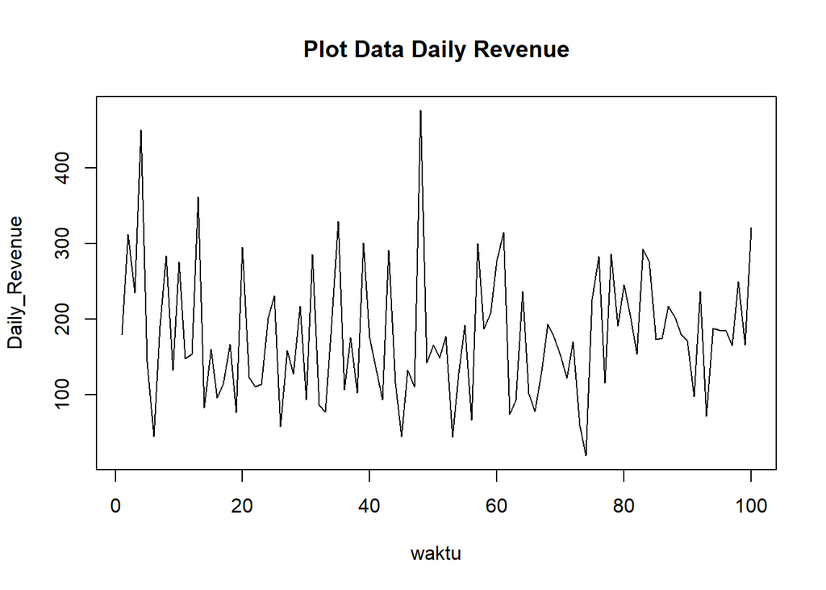

```r
plot.ts(fmcg.ts, lty=1, xlab="waktu", ylab="Daily_Revenue", main="Plot Data Daily Revenue")
```

Dari plot terlihat bahwa data tidak memiliki plot musiman yang jelas. Data tampak berfluktuasi di sekitar nilai tengah yang konstan (tidak ada tren naik atau pun turun). Lebar pita juga tampak relatif seragam meskipun ada beberapa lonjakan ekstrim.

Sehingga kita akan membagi data dengan:

- Training data: 80% (periode 1-80)
- Testing data: 20% (periode 81-100)

### 3.2 Plot Data Training

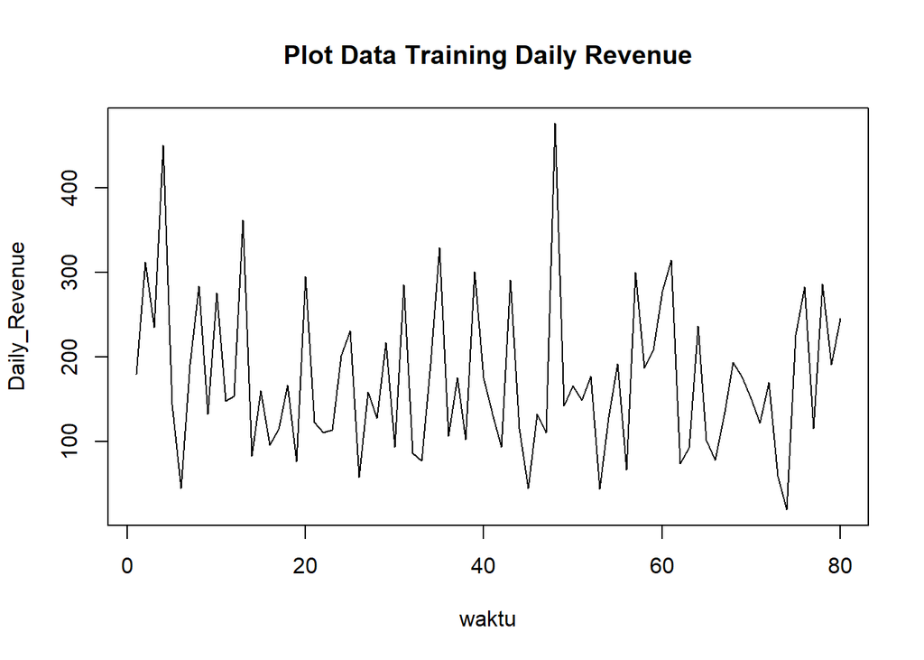

```r
train_data <- fmcg.ts[1:80]
plot.ts(train_data, lty=1, xlab="waktu", ylab="Daily_Revenue", main="Plot Data Training Daily Revenue")
```

Dari plot terlihat bahwa data tidak memiliki plot musiman yang jelas. Data tampak berfluktuasi di sekitar nilai tengah yang konstan (tidak ada tren naik atau pun turun). Lebar pita juga tampak relatif seragam meskipun ada beberapa lonjakan ekstrim.

### 3.3 Plot Data Testing

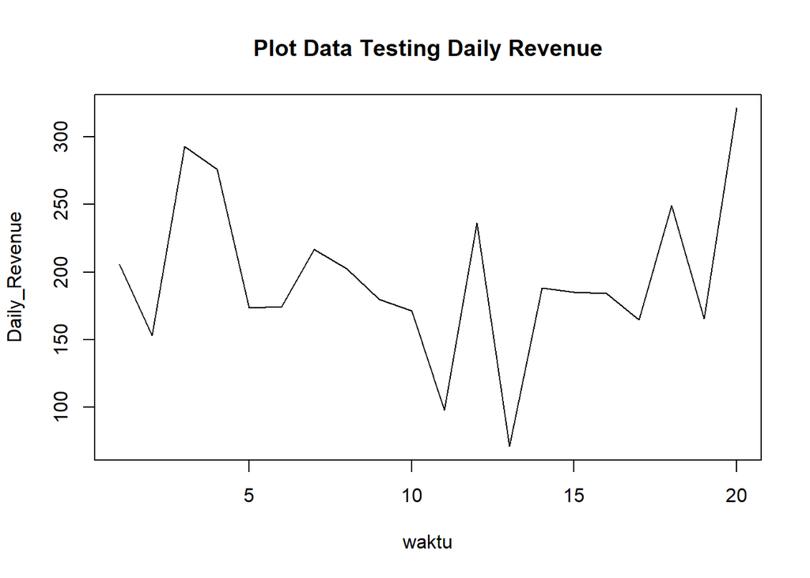

```r
test_data <- fmcg.ts[81:100]
plot.ts(test_data, lty=1, xlab="waktu", ylab="Daily_Revenue", main="Plot Data Testing Daily Revenue")
```

## 4 Uji Stationeritas Data

### 4.1 Plot ACF

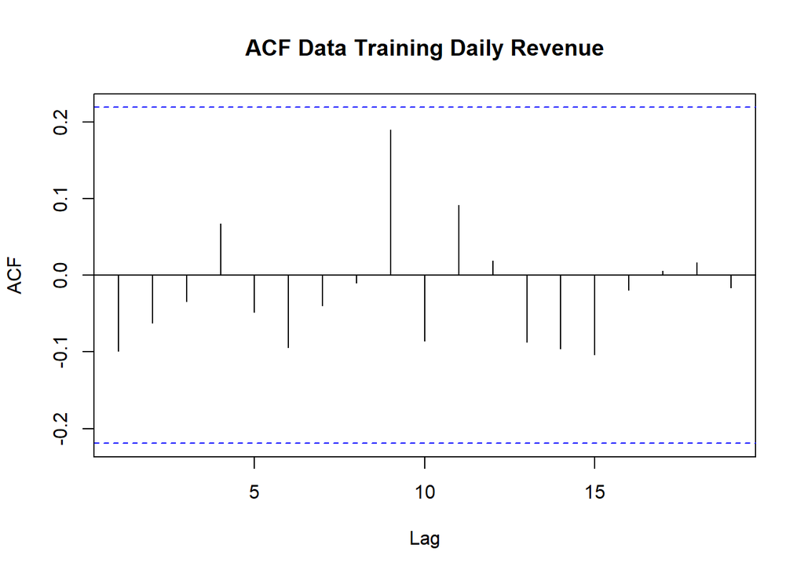

```r
acf(train_data, main="ACF Data Training Daily Revenue")
```

Plot ACF menunjukkan korelasi antara suatu nilai deret waktu dengan nilai-nilai masa lalunya (lag). Garis putus-putus biru menunjukkan batas signifikansi.

Nah, indikasi yang terlihat pada plot ACF adalah menunjukkan korelasi yang turun dengan cepat bukan turun secara perlahan/tails off. Artinya data ini stationer dalam rataan (d=0). Akan dibuktikan dengan uji statistik.

### 4.2 Uji ADF

```r
tseries::adf.test(train_data)
```

```
##
##  Augmented Dickey-Fuller Test
##
## data:  train_data
## Dickey-Fuller = -4.5962, Lag order = 4, p-value = 0.01
## alternative hypothesis: stationary
```

Hipotesis:

$H_0$: Data tidak stasioner dalam rataan (memiliki unit root)

$H_1$: Data stasione dalam rataan

Karena p-value (0.01) lebih kecil dari α (0.05), maka Tolak H0, dapat disimpulkan bahwa **data training stationer dalam rataan** pada taraf nyata 5%.

### 4.3 Plot Box-Cox

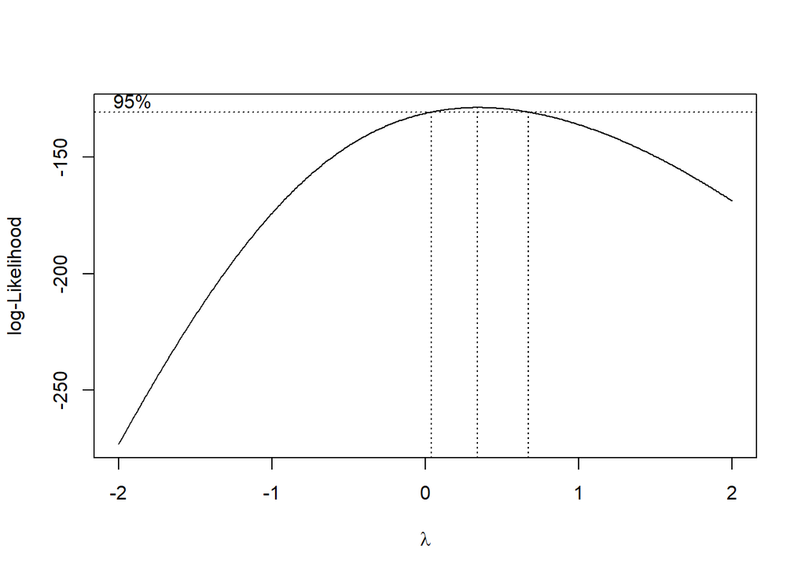

```r
index <- seq (1:80)
bc = MASS :: boxcox(train_data~index,lambda = seq(-2,2, by=0.01))
```

```r
lambda=bc$x[which.max(bc$y)]
lambda
```

```
## [1] 0.34
```

```r
bc$x[bc$y > max(bc$y) - 1/2 * qchisq(.95,1)]
```

```
##  [1] 0.04 0.05 0.06 0.07 0.08 0.09 0.10 0.11 0.12 0.13 0.14 0.15 0.16 0.17 0.18
## [16] 0.19 0.20 0.21 0.22 0.23 0.24 0.25 0.26 0.27 0.28 0.29 0.30 0.31 0.32 0.33
## [31] 0.34 0.35 0.36 0.37 0.38 0.39 0.40 0.41 0.42 0.43 0.44 0.45 0.46 0.47 0.48
## [46] 0.49 0.50 0.51 0.52 0.53 0.54 0.55 0.56 0.57 0.58 0.59 0.60 0.61 0.62 0.63
## [61] 0.64 0.65 0.66 0.67
```

Plot Boxcox menunjukkan nilai *rounded value* ($\lambda$) optimum sebesar **0.34** dan pada selang kepercayaan 95% nilai memiliki batas bawah **0.04** dan batas atas **0.67**. Selang tersebut tidak memuat nilai satu sehingga dapat dikatakan bahwa data bangkitan **tidak stasioner dalam ragam.**

### 4.4 Penanganan Ketidakstationeran Data

Karena data tidak stationer dalam ragam makan dilakukan transformasi Box-Cox dengan nilai $\lambda$ = 0.34

akan digunakan rumus boxcox standar yaitu

$$y_t^{(\lambda)} = \begin{cases}
\frac{y_t^\lambda - 1}{\lambda} & \text{untuk } \lambda \neq 0 \\
\ln(y_t) & \text{untuk } \lambda = 0 \end{cases}$$

```r
lambda_optimum <- 0.34

train_data_bc <- (train_data^lambda_optimum - 1) / lambda_optimum
```

### 4.5 Plot Data Training Setelah Transformasi Box-Cox

#### 4.5.1 Plot ACF

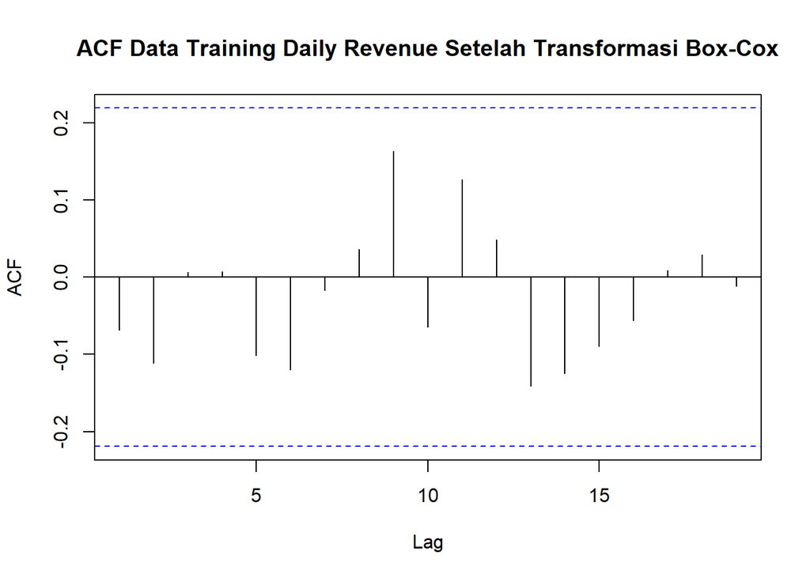

```r
acf(train_data_bc, main="ACF Data Training Daily Revenue Setelah Transformasi Box-Cox")
```

Plot ACF menunjukkan korelasi yang turun dengan cepat bukan turun secara perlahan/tails off. Artinya data ini **stationer dalam rataan** (d=0). Akan dibuktikan dengan uji statistik.

#### 4.5.2 Uji ADF

```r
tseries::adf.test(train_data_bc)
```

```
##
##  Augmented Dickey-Fuller Test
##
## data:  train_data_bc
## Dickey-Fuller = -4.8835, Lag order = 4, p-value = 0.01
## alternative hypothesis: stationary
```

Karena p-value (0.01) lebih kecil dari α (0.05), maka Tolak $H_0$, dapat disimpulkan bahwa data training **stationer dalam rataan** pada taraf nyata 5%.

#### 4.5.3 Plot Box-cox

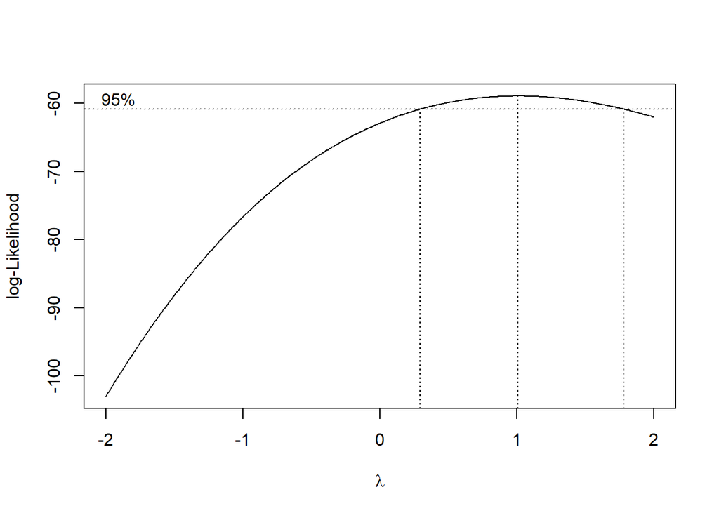

```r
index <- seq (1:80)
bc = MASS :: boxcox(train_data_bc~index,lambda = seq(-2,2, by=0.01))
```

```r
lambda=bc$x[which.max(bc$y)]
lambda
```

```
## [1] 1.01
```

```r
bc$x[bc$y > max(bc$y) - 1/2 * qchisq(.95,1)]
```

```
##   [1] 0.30 0.31 0.32 0.33 0.34 0.35 0.36 0.37 0.38 0.39 0.40 0.41 0.42 0.43 0.44
##  [16] 0.45 0.46 0.47 0.48 0.49 0.50 0.51 0.52 0.53 0.54 0.55 0.56 0.57 0.58 0.59
##  [31] 0.60 0.61 0.62 0.63 0.64 0.65 0.66 0.67 0.68 0.69 0.70 0.71 0.72 0.73 0.74
##  [46] 0.75 0.76 0.77 0.78 0.79 0.80 0.81 0.82 0.83 0.84 0.85 0.86 0.87 0.88 0.89
##  [61] 0.90 0.91 0.92 0.93 0.94 0.95 0.96 0.97 0.98 0.99 1.00 1.01 1.02 1.03 1.04
##  [76] 1.05 1.06 1.07 1.08 1.09 1.10 1.11 1.12 1.13 1.14 1.15 1.16 1.17 1.18 1.19
##  [91] 1.20 1.21 1.22 1.23 1.24 1.25 1.26 1.27 1.28 1.29 1.30 1.31 1.32 1.33 1.34
## [106] 1.35 1.36 1.37 1.38 1.39 1.40 1.41 1.42 1.43 1.44 1.45 1.46 1.47 1.48 1.49
## [121] 1.50 1.51 1.52 1.53 1.54 1.55 1.56 1.57 1.58 1.59 1.60 1.61 1.62 1.63 1.64
## [136] 1.65 1.66 1.67 1.68 1.69 1.70 1.71 1.72 1.73 1.74 1.75 1.76 1.77 1.78
```

lambda optimum sebesar **1.01** dan pada selang kepercayaan 95% nilai memiliki batas bawah **0.30** dan batas atas **1.78**. Selang tersebut memuat nilai satu sehingga dapat dikatakan bahwa data bangkitan **sudah stasioner dalam ragam.**

#### 4.5.4 Kesimpulan data setelah transformasi box-cox

Setelah dilakukan transformasi **data sudah stationer baik stationer dalam rataan maupun ragam,** sehingga tidak perlu dilakukan differencing (d=0). Selanjutnya akan dilakukan pemodelan.

## 5 Identifikasi Model

Setelah dilakukan penanganan transformasi box-cox ketidakstationeran data, maka akan dilakukan identifikasi model dengan plot ACF dan PACF.

### 5.1 Plot ACF

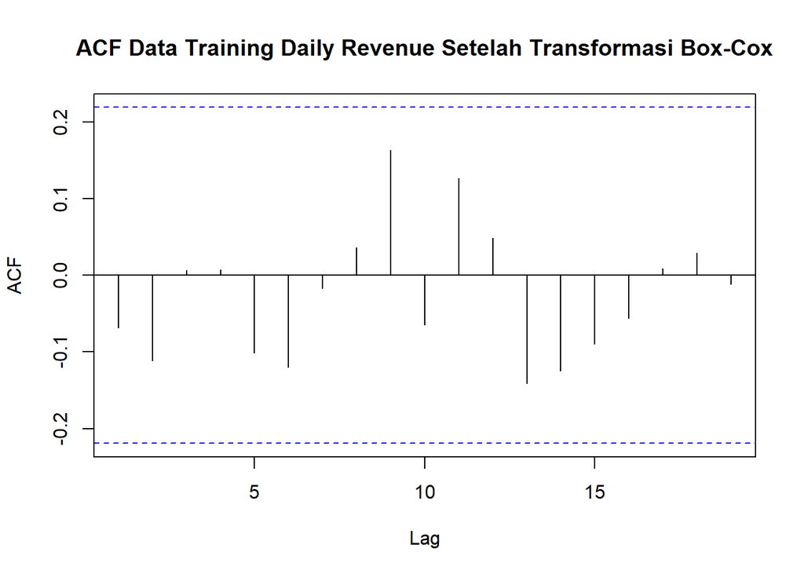

```r
acf(train_data_bc, main="ACF Data Training Daily Revenue Setelah Transformasi Box-Cox")
```

Semua lag berada di dalam batas signifikansi.

### 5.2 Plot PACF

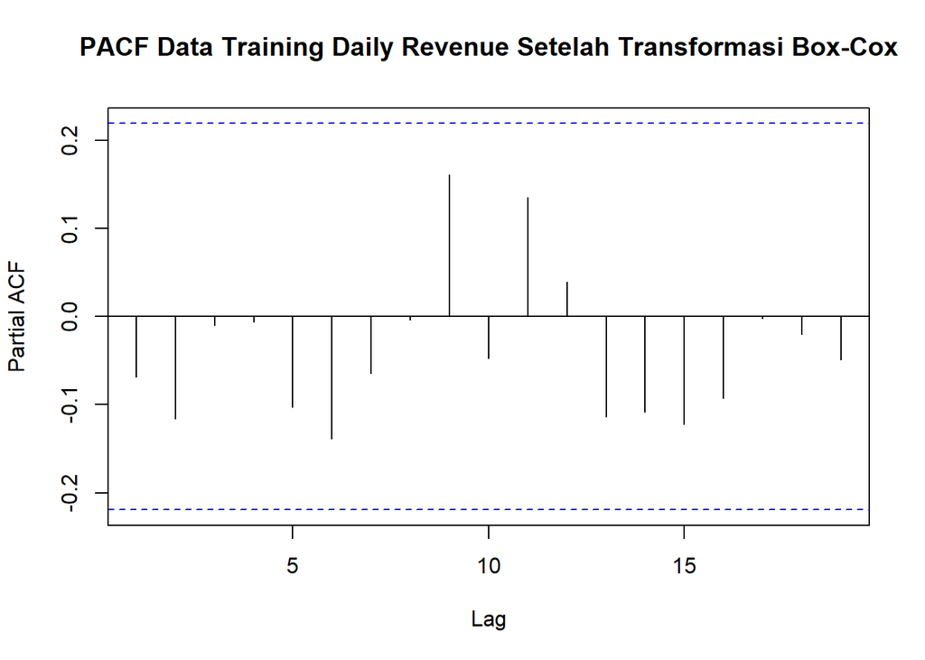

```r
pacf(train_data_bc, main="PACF Data Training Daily Revenue Setelah Transformasi Box-Cox")
```

Semua lag berada di dalam batas signifikansi.

**Dari plot ACF dan PACF tidak ada lag yang signifikan, sehingga model yang dapat digunakan adalah model ARIMA(0,0,0).**

### 5.3 Plot EACF

```r
eacf(train_data_bc)
```

```
## AR/MA
##   0 1 2 3 4 5 6 7 8 9 10 11 12 13
## 0 o o o o o o o o o o o  o  o  o
## 1 x o o o o o o o o o o  o  o  o
## 2 o o o o o o o o o o o  o  o  o
## 3 x o o o o o o o o o o  o  o  o
## 4 o x o o o o o o o o o  o  o  o
## 5 x o o o o o o o o o o  o  o  o
## 6 x o x o o o o o o o o  o  o  o
## 7 o o o o o o o o o o o  o  o  o
```

Identifikasi model menggunakan plot EACF dilakukan dengan melihat ujung segitiga pada pola segitiga nol. **Dalam hal ini model tentatif yang terbentuk adalah ARIMA(0,0,0), ARIMA(1,0,1), ARIMA(2,0,0), ARIMA (3,0,1)**

## 6 Pendugaan Parameter Model Tentatif

### 6.1 ARIMA (0,0,0)

```r
model1.da=Arima(train_data_bc, order=c(0,0,0),method="ML")
summary(model1.da) #AIC=410.69
```

```
## Series: train_data_bc
## ARIMA(0,0,0) with non-zero mean
##
## Coefficients:
##          mean
##       13.4918
## s.e.   0.3436
##
## sigma^2 = 9.567:  log likelihood = -203.34
## AIC=410.69   AICc=410.85   BIC=415.45
##
## Training set error measures:
##                         ME     RMSE      MAE       MPE     MAPE      MASE
## Training set -4.884981e-15 3.073664 2.463951 -6.315481 20.67584 0.6553194
##                     ACF1
## Training set -0.06825972
```

```r
lmtest::coeftest(model1.da) #seluruh parameter signifikan
```

```
##
## z test of coefficients:
##
##           Estimate Std. Error z value  Pr(>|z|)
## intercept 13.49180    0.34365  39.261 < 2.2e-16 ***
## ---
## Signif. codes:  0 '***' 0.001 '**' 0.01 '*' 0.05 '.' 0.1 ' ' 1
```

### 6.2 ARIMA (1,0,1)

```r
model2.da=Arima(train_data_bc, order=c(1,0,1),method="ML")
summary(model2.da) #AIC=409.89
```

```
## Series: train_data_bc
## ARIMA(1,0,1) with non-zero mean
##
## Coefficients:
##          ar1      ma1     mean
##       0.8068  -1.0000  13.3514
## s.e.  0.0830   0.0387   0.0658
##
## sigma^2 = 8.987:  log likelihood = -200.95
## AIC=409.89   AICc=410.43   BIC=419.42
##
## Training set error measures:
##                     ME     RMSE      MAE       MPE     MAPE     MASE       ACF1
## Training set 0.3435103 2.941122 2.276645 -3.225446 18.79782 0.605503 0.02676991
```

```r
lmtest::coeftest(model2.da) #seluruh parameter signifikan
```

```
##
## z test of coefficients:
##
##            Estimate Std. Error  z value  Pr(>|z|)
## ar1        0.806812   0.082960   9.7253 < 2.2e-16 ***
## ma1       -1.000000   0.038678 -25.8546 < 2.2e-16 ***
## intercept 13.351430   0.065841 202.7827 < 2.2e-16 ***
## ---
## Signif. codes:  0 '***' 0.001 '**' 0.01 '*' 0.05 '.' 0.1 ' ' 1
```

### 6.3 ARIMA (2,0,0)

```r
model3.da=Arima(train_data_bc, order=c(2,0,0),method="ML")
summary(model3.da) #AIC=413.2
```

```
## Series: train_data_bc
## ARIMA(2,0,0) with non-zero mean
##
## Coefficients:
##           ar1      ar2     mean
##       -0.0774  -0.1185  13.4780
## s.e.   0.1111   0.1118   0.2857
##
## sigma^2 = 9.631:  log likelihood = -202.6
## AIC=413.2   AICc=413.73   BIC=422.73
##
## Training set error measures:
##                       ME    RMSE      MAE       MPE     MAPE      MASE
## Training set 0.007727768 3.04457 2.410412 -6.140925 20.22498 0.6410799
##                      ACF1
## Training set -0.001812324
```

```r
lmtest::coeftest(model3.da) #tidak ada parameter signifikan
```

```
##
## z test of coefficients:
##
##            Estimate Std. Error z value Pr(>|z|)
## ar1       -0.077426   0.111121 -0.6968   0.4859
## ar2       -0.118508   0.111761 -1.0604   0.2890
## intercept 13.478006   0.285732 47.1701   <2e-16 ***
## ---
## Signif. codes:  0 '***' 0.001 '**' 0.01 '*' 0.05 '.' 0.1 ' ' 1
```

### 6.4 ARIMA (3,0,1)

```r
model4.da=Arima(train_data_bc, order=c(3,0,1),method="ML")
summary(model4.da) #AIC=413.69
```

```
## Series: train_data_bc
## ARIMA(3,0,1) with non-zero mean
##
## Coefficients:
##          ar1      ar2     ar3     ma1     mean
##       0.8401  -0.0649  0.0219  -1.000  13.3479
## s.e.  0.1132   0.1464  0.1206   0.039   0.0661
##
## sigma^2 = 9.195:  log likelihood = -200.85
## AIC=413.69   AICc=414.84   BIC=427.98
##
## Training set error measures:
##                     ME     RMSE      MAE       MPE     MAPE      MASE
## Training set 0.3525764 2.936055 2.277604 -3.109321 18.75282 0.6057581
##                      ACF1
## Training set -0.006342033
```

```r
lmtest::coeftest(model4.da) #2 parameter signifikan
```

```
##
## z test of coefficients:
##
##            Estimate Std. Error  z value  Pr(>|z|)
## ar1        0.840124   0.113225   7.4199 1.172e-13 ***
## ar2       -0.064875   0.146405  -0.4431    0.6577
## ar3        0.021854   0.120572   0.1813    0.8562
## ma1       -1.000000   0.039027 -25.6233 < 2.2e-16 ***
## intercept 13.347910   0.066052 202.0821 < 2.2e-16 ***
## ---
## Signif. codes:  0 '***' 0.001 '**' 0.01 '*' 0.05 '.' 0.1 ' ' 1
```

Berdasarkan pendugaan parameter di atas, nilai **AIC terkecil** dimiliki oleh model ARIMA(1,0,1) dan parameter model ARIMA(1,0,1) juga **seluruhnya signifikan** sehingga model yang dipilih adalah model **ARIMA(1,0,1).**

## 7 Analisis Sisaan

Model terbaik hasil identifikasi kemudian dicek asumsi sisaannya. Sisaan model ARIMA harus memenuhi asumsi normalitas, kebebasan sisaan, dan kehomogenan ragam. Diagnostik model dilakukan secara eksplorasi dan uji formal.

### 7.1 Eksplorasi Sisaan

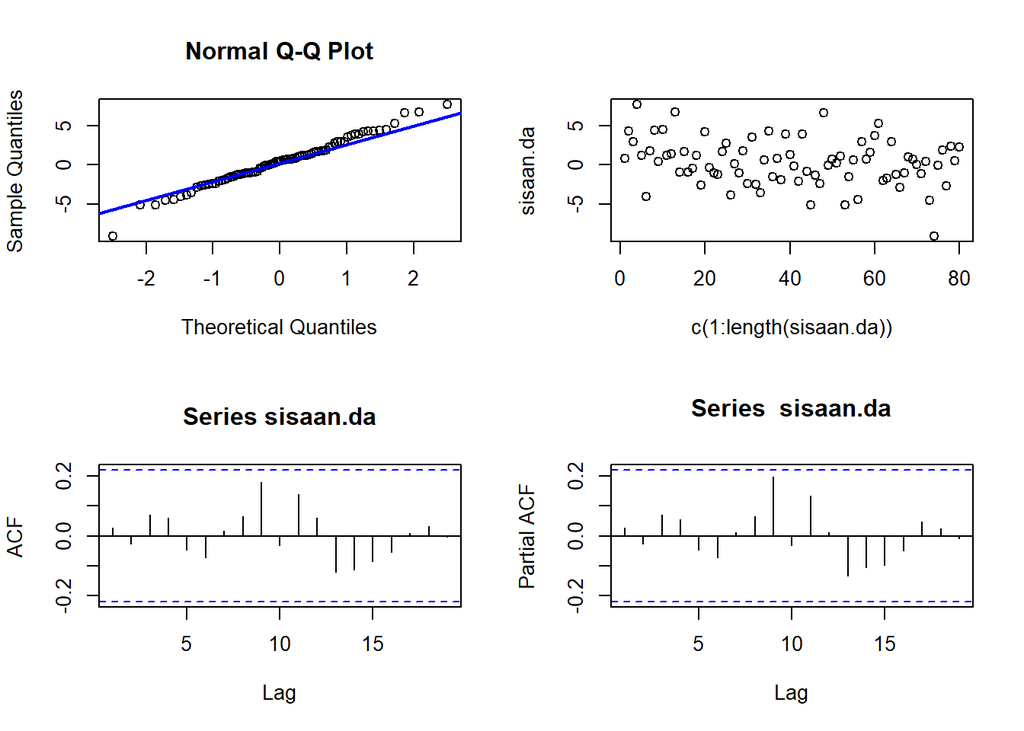

```r
sisaan.da <- model2.da$residuals
par(mfrow=c(2,2))
qqnorm(sisaan.da)
qqline(sisaan.da, col = "blue", lwd = 2)
plot(c(1:length(sisaan.da)),sisaan.da)
acf(sisaan.da)
pacf(sisaan.da)
```

```r
par(mfrow = c(1,1))
```

1. Normal Q-Q Plot Secara visual, sisaan menunjukkan **distribusi tak normal**, ada sedikit penyimpangan di bagian ekor.
2. Plot sisaan vs waktu, rata-rata siaan tampaknya **bergerak di sekitar nol**, lebar pita penyebaran juga tampak seragam.
3. Plot ACF Semua batang autokorelasi (dari Lag 1 hingga Lag 20) berada di dalam batas signifikansi, ini menunjukkan bahwa **sisaan saling bebas.**
4. Plot PACF Semua batang korelasi parsial (dari Lag 1 hingga Lag 20) berada di dalam batas signifikansi (garis putus-putus biru), mengkonfirmasi bahwa sisaan adalah **White Noise.**

Akan dibuktikan dengan uji lanjut

### 7.2 Uji Formal

#### 7.2.1 Normalitas

```r
ks.test(sisaan.da,"pnorm")  #tak tolak H0 > sisaan menyebar normal
```

```
##
##  Exact one-sample Kolmogorov-Smirnov test
##
## data:  sisaan.da
## D = 0.25946, p-value = 3.073e-05
## alternative hypothesis: two-sided
```

Pada tahapan ini uji formal yang digunakan untuk normalitas adalah uji Kolmogorov-Smirnov (KS). Hipotesis pada uji KS adalah sebagai berikut.

$H_0$ : Sisaan menyebar normal

$H_1$ : Sisaan tidak menyebar normal

Berdasarkan uji KS tersebut, didapat *p-value* sebesar 0.00003 yang kurang dari taraf nyata 5% sehingga tolak $H_0$ dan menandakan bahwa sisaan **tidak menyebar normal**. Hal ini sesuai dengan hasil eksplorasi menggunakan plot kuantil-kuantil normal.

#### 7.2.2 Sisaan saling bebas

```r
Box.test(sisaan.da, type = "Ljung")  #tak tolak H0 > sisaan saling bebas
```

```
##
##  Box-Ljung test
##
## data:  sisaan.da
## X-squared = 0.059507, df = 1, p-value = 0.8073
```

Selanjutnya akan dilakukan uji formal untuk kebebasan sisaan menggunakan uji Ljung-Box. Hipotesis yang digunakan adalah sebagai berikut.

$H_0$ : Sisaan saling bebas

$H_1$ : Sisaan tidak tidak saling bebas

Berdasarkan uji Ljung-Box tersebut, didapat *p-value* sebesar 0.8073 yang lebih besar dari taraf nyata 5% sehingga tak tolak $H_0$ dan menandakan bahwa **sisaan saling bebas**.

#### 7.2.3 Kehomogenan ragam

```r
Box.test((sisaan.da)^2, type = "Ljung")  #tak tolak H0 > sisaan homogen
```

```
##
##  Box-Ljung test
##
## data:  (sisaan.da)^2
## X-squared = 0.58424, df = 1, p-value = 0.4447
```

Hipotesis yang digunakan untuk uji kehomogenan ragam adalah sebagai berikut.

$H_0$ : Ragam sisaan homogen

$H_1$ : Ragam sisaan tidak homogen

Berdasarkan uji Ljung-Box terhadap sisaan kuadrat tersebut, didapat *p-value* sebesar 0.4447 yang lebih dari taraf nyata 5% sehingga tak tolak $H_0$ dan menandakan bahwa **ragam sisaan homogen.**

#### 7.2.4 Nilai tengah sama dengan 0

```r
t.test(sisaan.da, mu = 0, conf.level = 0.95)  #tak tolak h0 > nilai tengah sisaan sama dengan 0
```

```
##
##  One Sample t-test
##
## data:  sisaan.da
## t = 1.0453, df = 79, p-value = 0.2991
## alternative hypothesis: true mean is not equal to 0
## 95 percent confidence interval:
##  -0.3106259  0.9976466
## sample estimates:
## mean of x
## 0.3435103
```

$H_0$ : nilai tengah sisaan sama dengan 0

$H_1$ : nilai tengah sisaan tidak sama dengan 0

Berdasarkan uji-ttersebut, didapat *p-value* sebesar 0.2991 yang lebih besar dari taraf nyata 5% sehingga tak tolak $H_0$ dan menandakan bahwa **nilai tengah sisaan sama dengan nol.**

#### 7.2.5 Kesimpulan Uji Sisaan dengan uji formal

1. Sisaan tidak menyebar normal
2. Sisaan saling bebas
3. Ragam sisaan homogen
4. Nilai tengah sisaan sama dengan nol

## 8 Overfitting

Tahapan selanjutnya adalah *overfitting* dilakukan dengan menaikkan orde AR(p) dan MA(q) dari model ARIMA(1,0,1) untuk melihat apakah terdapat model lain yang lebih baik dari model saat ini. Kandidat model *overfitting* adalah ARIMA(2,0,1) dan ARIMA(1,0,2).

```r
model2a.da=Arima(train_data_bc, order=c(2,0,1),method="ML")
summary(model2a.da) #411.72
```

```
## Series: train_data_bc
## ARIMA(2,0,1) with non-zero mean
##
## Coefficients:
##          ar1      ar2      ma1     mean
##       0.8384  -0.0499  -1.0000  13.3455
## s.e.  0.1127   0.1209   0.0393   0.0624
##
## sigma^2 = 9.071:  log likelihood = -200.86
## AIC=411.72   AICc=412.53   BIC=423.63
##
## Training set error measures:
##                     ME     RMSE     MAE       MPE     MAPE      MASE
## Training set 0.3598523 2.935555 2.27371 -3.055222 18.72411 0.6047224
##                      ACF1
## Training set -0.007469585
```

```r
lmtest::coeftest(model2a.da) #ar2 tidak signifikan
```

```
##
## z test of coefficients:
##
##            Estimate Std. Error  z value  Pr(>|z|)
## ar1        0.838421   0.112743   7.4365 1.034e-13 ***
## ar2       -0.049907   0.120912  -0.4128    0.6798
## ma1       -0.999997   0.039298 -25.4465 < 2.2e-16 ***
## intercept 13.345500   0.062410 213.8357 < 2.2e-16 ***
## ---
## Signif. codes:  0 '***' 0.001 '**' 0.01 '*' 0.05 '.' 0.1 ' ' 1
```

```r
model2b.da=Arima(train_data_bc, order=c(1,0,2),method="ML")
summary(model2b.da) #411.71
```

```
## Series: train_data_bc
## ARIMA(1,0,2) with non-zero mean
##
## Coefficients:
##          ar1      ma1      ma2     mean
##       0.7744  -0.9336  -0.0664  13.3454
## s.e.  0.1172   0.1611   0.1562   0.0621
##
## sigma^2 = 9.07:  log likelihood = -200.86
## AIC=411.71   AICc=412.52   BIC=423.62
##
## Training set error measures:
##                     ME    RMSE      MAE     MPE     MAPE      MASE         ACF1
## Training set 0.3600289 2.93535 2.274107 -3.0501 18.72286 0.6048281 -0.009637917
```

```r
lmtest::coeftest(model2b.da) #ma2 tidak signifikan
```

```
##
## z test of coefficients:
##
##            Estimate Std. Error  z value  Pr(>|z|)
## ar1        0.774433   0.117180   6.6089 3.872e-11 ***
## ma1       -0.933611   0.161098  -5.7953 6.820e-09 ***
## ma2       -0.066375   0.156247  -0.4248     0.671
## intercept 13.345437   0.062131 214.7950 < 2.2e-16 ***
## ---
## Signif. codes:  0 '***' 0.001 '**' 0.01 '*' 0.05 '.' 0.1 ' ' 1
```

```r
#model yang dipilih adalah model awal, yaitu ARIMA(1,0,1)
```

Berdasarkan kedua model hasil *overfitting* di atas, model ARIMA(2,0,1) dan ARIMA(1,0,2) memiliki **AIC yang lebih besar** dibandingkan dengan model ARIMA(1,0,1) dan parameter kedua model ARIMA(2,0,1) dan ARIMA(1,0,2) **tidak seluruhnya signifikan.** Oleh karena itu, model **ARIMA(1,0,1)** akan **tetap digunakan untuk melakukan peramalan.**

## 9 Peramalan

Peramalan dilakukan menggunakan fungsi `forecast()` . Contoh peramalan berikut ini dilakukan untuk 20 hari ke depan **(h=20 agar sesuai dengan panjang data uji)**

```r
ramalan <- forecast::forecast(model2.da, h = 20)
ramalan
```

```
##     Point Forecast    Lo 80    Hi 80    Lo 95    Hi 95
##  81       13.34333 9.479968 17.20669 7.434828 19.25183
##  82       13.34489 9.418219 17.27157 7.339562 19.35023
##  83       13.34616 9.378810 17.31350 7.278623 19.41369
##  84       13.34718 9.353577 17.34078 7.239493 19.45486
##  85       13.34800 9.337402 17.35859 7.214321 19.48167
##  86       13.34866 9.327040 17.37028 7.198122 19.49920
##  87       13.34920 9.320414 17.37798 7.187706 19.51069
##  88       13.34963 9.316192 17.38306 7.181020 19.51824
##  89       13.34998 9.313513 17.38644 7.176739 19.52321
##  90       13.35026 9.311825 17.38869 7.174008 19.52650
##  91       13.35048 9.310770 17.39020 7.172276 19.52869
##  92       13.35067 9.310119 17.39121 7.171183 19.53015
##  93       13.35081 9.309724 17.39190 7.170501 19.53113
##  94       13.35093 9.309490 17.39238 7.170080 19.53179
##  95       13.35103 9.309356 17.39270 7.169824 19.53223
##  96       13.35111 9.309284 17.39293 7.169673 19.53254
##  97       13.35117 9.309249 17.39309 7.169586 19.53275
##  98       13.35122 9.309236 17.39320 7.169540 19.53290
##  99       13.35126 9.309236 17.39328 7.169517 19.53300
## 100       13.35129 9.309242 17.39334 7.169509 19.53308
```

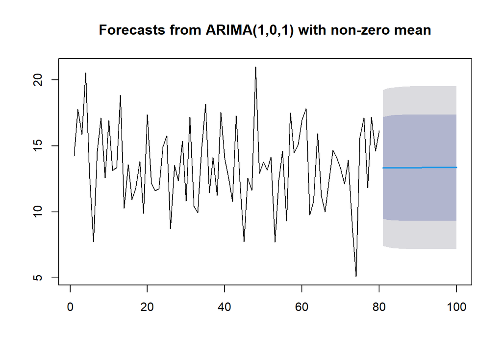

```r
data.ramalan <- ramalan$mean
plot(ramalan)
```

Berdasarkan hasil plot ramalan di atas, dapat dilihat bahwa ramalan ARIMA (1,0,1) cenderung stabil hingga akhir periode. Selanjutnya, dapat dicari nilai akurasi antara hasil ramalan dengan data uji sebagai berikut.

```r
# Transformasi balik (Inverse Box-Cox)

# Pastikan lambda bukan nol, jika lambda sangat dekat dengan nol, gunakan exp()
if (lambda_optimum != 0) {

  # Rumus untuk lambda TIDAK SAMA DENGAN nol
  hasil.ramalan.asli <- (data.ramalan* lambda_optimum + 1)^(1/lambda_optimum)

} else {

  # Jika lambda = 0, transformasi balik adalah eksponensial (exp)
  hasil.ramalan.asli <- exp(data.ramalan)

}

# Konversi hasil ramalan asli menjadi objek deret waktu (ts)
hasil.ramalan.asli.ts <- ts(hasil.ramalan.asli)
hasil.ramalan.asli.ts
```

```
## Time Series:
## Start = 1
## End = 20
## Frequency = 1
##  [1] 153.4758 153.5191 153.5541 153.5824 153.6052 153.6236 153.6384 153.6504
##  [9] 153.6600 153.6678 153.6741 153.6792 153.6833 153.6866 153.6893 153.6914
## [17] 153.6931 153.6945 153.6957 153.6966
```

```r
perbandingan.fmcg <- matrix(data = c(head(test_data, n = 20), head(hasil.ramalan.asli, n = 20)),
                            nrow = 20,
                            ncol = 2)

colnames(perbandingan.fmcg) <- c("Aktual (test_data)", "Hasil Forecast (Skala Asli)")

perbandingan.fmcg
```

```
##       Aktual (test_data) Hasil Forecast (Skala Asli)
##  [1,]             205.72                    153.4758
##  [2,]             153.30                    153.5191
##  [3,]             292.84                    153.5541
##  [4,]             276.04                    153.5824
##  [5,]             173.46                    153.6052
##  [6,]             174.66                    153.6236
##  [7,]             216.71                    153.6384
##  [8,]             202.31                    153.6504
##  [9,]             179.64                    153.6600
## [10,]             171.42                    153.6678
## [11,]              97.79                    153.6741
## [12,]             236.41                    153.6792
## [13,]              71.17                    153.6833
## [14,]             188.11                    153.6866
## [15,]             185.05                    153.6893
## [16,]             184.15                    153.6914
## [17,]             164.82                    153.6931
## [18,]             249.22                    153.6945
## [19,]             165.61                    153.6957
## [20,]             321.10                    153.6966
```

```r
accuracy(ts(head(hasil.ramalan.asli, n =20)),
         head(test_data, n = 20))
```

```
##                ME     RMSE      MAE      MPE     MAPE
## Test set 41.83347 71.61892 55.69513 11.83746 29.16029
```

Kesimpulan:

1. Model ARIMA(1,0,1) terpilih sebagai model terbaik berdasarkan nilai AIC terkecil dan seluruh parameter signifikan pada data yang di transformasi Box-Cox.
2. Hasil uji sisaan menunjukkan bahwa sisaan saling bebas, ragam sisaan homogen, dan nilai tengah sisaan sama dengan nol tetapi sisaan tidak menyebar normal.
3. Hasil peramalan dengan model ARIMA(1,0,1):

   3.1 **RMSE** = 71.61892, kesalahan ramalan (dalam skala asli) sangat besar.

   3.2 **MAPE** = 29.16029%, kesalahan persentase ramalan rata-rata hampir 30%, yang dianggap tidak akurat untuk peramalan bisnis.

   3.3 **Rentang aktual** = 71.17 hingga 321.10, data uji berfluktuasi liar

   3.4 **Rentang ramalan** = 153.47 hingga 153.69, Ramalan datar dan mendekati nilai 153.

## 10 Insight

Model ARMA(1,1) secara teknis adalah **model** **terbaik untuk menghilangkan autokorelasi** (berdasarkan diagnostik), tetapi **tidak memiliki kekuatan prediktif yang memadai**. Hasil peramalan menunjukkan bahwa data Daily Revenue terlalu volatil dan strukturnya terlalu lemah/acak untuk diprediksi secara akurat oleh model ARIMA sederhana. Dalam kasus ini, model ARIMA yang ‘terbaik’ secara statistik masih menghasilkan ramalan yang tidak berguna secara praktis (ramalan datar) karena data aktual berperilaku sangat acak. Sehingga, **Model ARIMA(1,0,1) kurang cocok** untuk meramalkan data Daily Revenue yang **memiliki fluktuasi tinggi.**